# Prediction Model for Exercise Manner of Machine Learning

Xuanru Shen

1/7/2017

# Abstract

In order to make prediction of the exercise manner, we are supposed to focus on the personal activity data of 6 people. By making analysis and trials, using machine learning methods we have been learned in this course, predict the manner for the testing set and make submition.

# Data Exploratory

There are two datasets, training and testing. Training (19622 by 160) and testing (20 by 160). classe in training set is the outcome(dependent variable) that we want to predict. The outcome has five levels, A,B,C,D,E, which indicate it would not be a linear regression. We also set the levels as a factor vector for further usage.

Based on the data in pml-testing.csv, there are only 60 columns having valuable info, the remaining 100 columns are NA. In order to build model to predict the result in testing set, we want to make usage of those remaining 60 variables. Then we get the subset of the training data with only 60 variables.

Among those 60 variables, one is the dependent variable(outcome), first 7 variables are name, time, and window info which is probably not essential to the model. We are not including those at this time. In total, we have 52 predictor candidates, one outcome. With too many of predictors, first we want to select some of them which make big contribution to the outcome, also, not losing many information.

## Data cleaning

```r
library(rpart)
library(caret)
library(rattle)
library(ggplot2)
library(gbm)
library(randomForest)
library(e1071)

# Read data
if(exists("training")==FALSE){
  training <- read.csv("~/Downloads/pml-training.csv",na.string = "NA",stringsAsFactors = FALSE)
}

if(exists("testing")==FALSE){
  testing <- read.csv("~/Downloads/pml-testing.csv",na.string = "NA",stringsAsFactors = FALSE)
}
```

```r
# delete columns that only contains NA
training<-training[,as.numeric(colSums(is.na(testing))<nrow(testing)) == 1]
testing <- testing[,colSums(is.na(testing))<nrow(testing)]

# Creat training and test sets
inTrain <- createDataPartition(y=training$classe,p=0.75,list = FALSE)
Trainset <- training[inTrain,]
Testset <- training[-inTrain,]
dim(Trainset);dim(Testset)
```

```
## [1] 14718    60
```

```
## [1] 4904   60
```

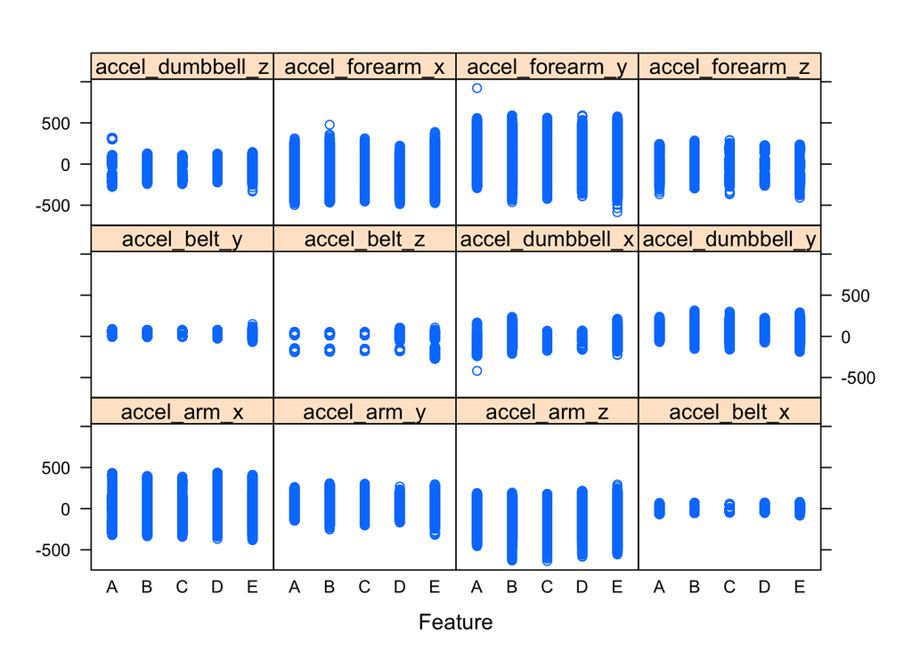

```r
predictors <- Trainset[,8:60]
predictors$classe <- factor(predictors$classe)

featurePlot(x<-predictors[,c(8,9,10,21,22,23,34,35,36,47,48,49)],y<-predictors[,53])
```

I randomly choosing some of the variables and see the feature plots with outcome.

```r
# pca
smallt <- prcomp(predictors[,1:52])
summary(smallt)
```

```
## Importance of components:
##                             PC1      PC2      PC3      PC4       PC5
## Standard deviation     600.0337 534.7542 472.2438 375.5960 355.83211
## Proportion of Variance   0.2641   0.2097   0.1636   0.1035   0.09287
## Cumulative Proportion    0.2641   0.4738   0.6374   0.7409   0.83374
##                              PC6       PC7       PC8       PC9     PC10
## Standard deviation     255.61961 201.06686 172.25671 157.84839 118.4973
## Proportion of Variance   0.04793   0.02965   0.02176   0.01828   0.0103
## Cumulative Proportion    0.88166   0.91132   0.93308   0.95135   0.9617
##                            PC11     PC12    PC13     PC14    PC15     PC16
## Standard deviation     97.26315 89.91234 76.5710 68.73079 61.8071 56.61539
## Proportion of Variance  0.00694  0.00593  0.0043  0.00346  0.0028  0.00235
## Cumulative Proportion   0.96859  0.97452  0.9788  0.98229  0.9851  0.98744
##                            PC17     PC18     PC19     PC20     PC21
## Standard deviation     52.62851 49.93840 48.39638 41.95946 37.26277
## Proportion of Variance  0.00203  0.00183  0.00172  0.00129  0.00102
## Cumulative Proportion   0.98947  0.99130  0.99302  0.99431  0.99533
##                            PC22     PC23     PC24     PC25     PC26
## Standard deviation     34.90168 32.75757 30.70459 25.50192 22.97090
## Proportion of Variance  0.00089  0.00079  0.00069  0.00048  0.00039
## Cumulative Proportion   0.99622  0.99701  0.99770  0.99818  0.99856
##                            PC27     PC28     PC29     PC30     PC31
## Standard deviation     21.59698 20.52467 17.16303 15.14902 13.67816
## Proportion of Variance  0.00034  0.00031  0.00022  0.00017  0.00014
## Cumulative Proportion   0.99891  0.99922  0.99943  0.99960  0.99974
##                           PC32    PC33    PC34    PC35    PC36    PC37
## Standard deviation     9.92674 7.55968 7.29664 6.71718 6.06392 4.63829
## Proportion of Variance 0.00007 0.00004 0.00004 0.00003 0.00003 0.00002
## Cumulative Proportion  0.99981 0.99985 0.99989 0.99992 0.99995 0.99997
##                           PC38    PC39    PC40  PC41  PC42  PC43   PC44
## Standard deviation     3.74836 3.49197 3.37136 1.958 1.517 1.089 0.4633
## Proportion of Variance 0.00001 0.00001 0.00001 0.000 0.000 0.000 0.0000
## Cumulative Proportion  0.99998 0.99999 0.99999 1.000 1.000 1.000 1.0000
##                          PC45   PC46   PC47   PC48   PC49   PC50   PC51
## Standard deviation     0.3935 0.3581 0.3144 0.2404 0.2009 0.1857 0.1043
## Proportion of Variance 0.0000 0.0000 0.0000 0.0000 0.0000 0.0000 0.0000
## Cumulative Proportion  1.0000 1.0000 1.0000 1.0000 1.0000 1.0000 1.0000
##                          PC52
## Standard deviation     0.0369
## Proportion of Variance 0.0000
## Cumulative Proportion  1.0000
```

By principal component analysis, we can see for the first 5 components, it could explain above 80%, for the fist 7 components, the proportion would exceed 90%. We know that we may not need this much variables for modeling, but few.

# Method exploring

Since it is a supervised the learning, we are not using unsupervised method like svm, clustering here.

To make our prediction much more convincing and accurate, we use cross validation and split our “training set” to the train(75%) and test(25%). By calculating the accuracy about predict the Testset outcome among those ML methods, we could get the best method.

# ML model comparison

we use random forest, linear discriminant analysis, boosting, bagging and classification tree here.

Use caret, randomForest package, and use predict to get the predictions based on the method I pick, then compare the prediction with the true result to get the accuracy rate. By setting classe as the outcome, other remaining variables as predictors, using tree based method to train our data and get certain results.

```r
fit2<- train(classe~.,data = predictors,method="rpart") # classification tree
pred2 <- predict(fit2,Testset)
confusionMatrix(Testset$classe,pred2)$overall[1]
```

```
##  Accuracy
## 0.4893964
```

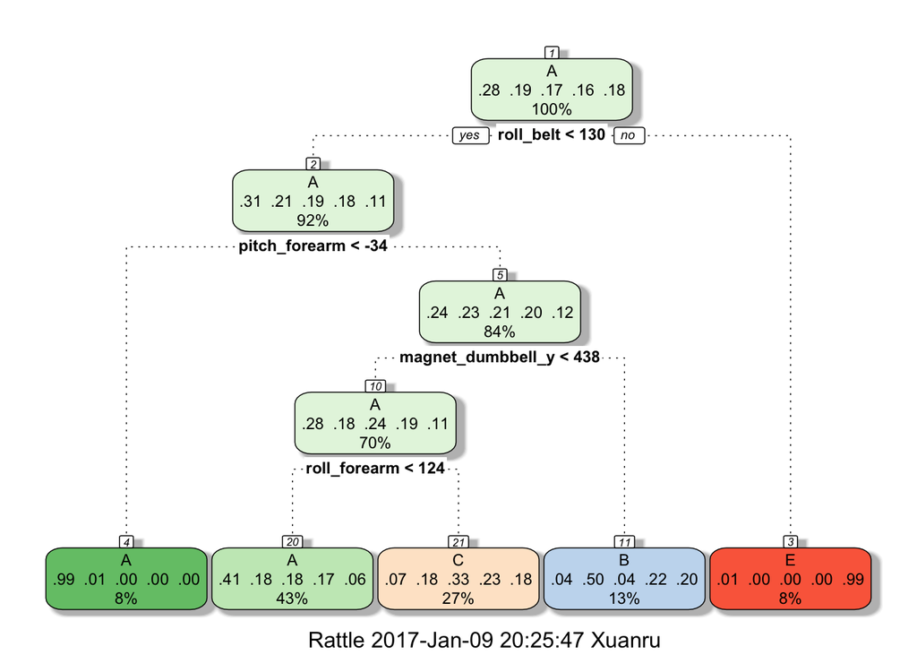

```r
fancyRpartPlot(fit2$finalModel)
```

```r
fit3<- randomForest(classe~.,data = predictors) # random forest
fit4<- train(classe~.,data = predictors,method="lda") # linear discriminant analysis
fit5<- train(classe~.,data = predictors,method="gbm") # boosting
fit6<- train(classe~.,data = predictors,method="treebag") # bagging
```

```r
pred3 <- predict(fit3,Testset)
confusionMatrix(Testset$classe,pred3)$overall[1]
```

```
##  Accuracy
## 0.9940865
```

```r
pred4 <- predict(fit4,Testset)
confusionMatrix(Testset$classe,pred4)$overall[1]
```

```
##  Accuracy
## 0.6949429
```

```r
pred5 <- predict(fit5,Testset)
confusionMatrix(Testset$classe,pred5)$overall[1]
```

```
##  Accuracy
## 0.9632953
```

```r
pred6 <- predict(fit6,Testset)
confusionMatrix(Testset$classe,pred6)$overall[1]
```

```
##  Accuracy
## 0.9840946
```

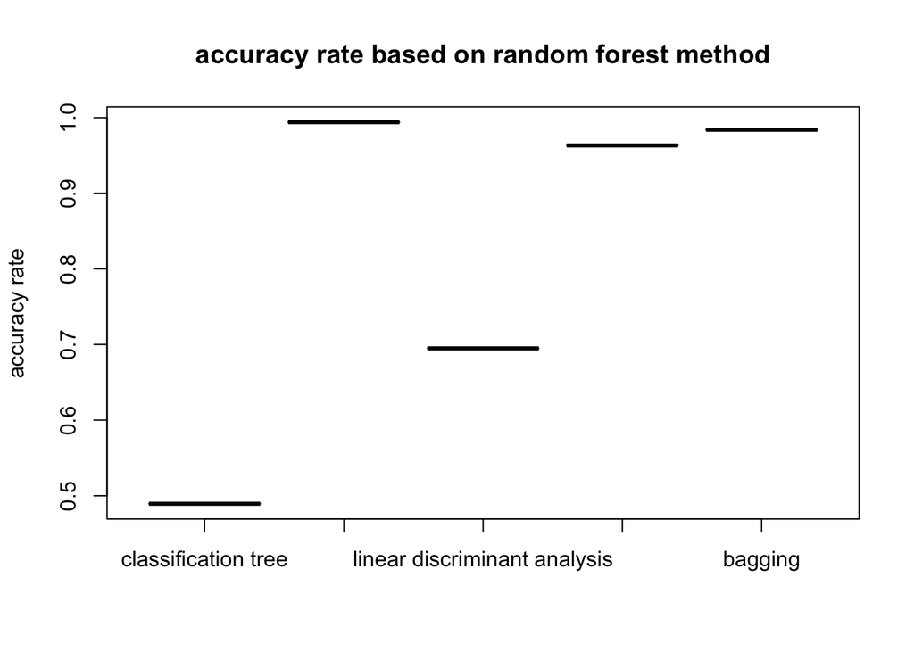

```r
accurateMatrix<-data.frame(confusionMatrix(Testset$classe,pred2)$overall[1],confusionMatrix(Testset$classe,pred3)$overall[1],confusionMatrix(Testset$classe,pred4)$overall[1],confusionMatrix(Testset$classe,pred5)$overall[1],confusionMatrix(Testset$classe,pred6)$overall[1])

colnames(accurateMatrix) <- c("classification tree","random forest","linear discriminant analysis","boosting","bagging")

boxplot(accurateMatrix,names=c("classification tree","random forest","linear discriminant analysis","boosting","bagging"), ylab="accuracy rate",main="accuracy rate based on random forest method")
```

From the boxplot, we can easily compare among the five. Random forest has highest accuracy rate

Using the testing data, applying my trained method, the prediction would be saved in predResult. I write the predict result to the location for quiz usage.

```r
predResult <- predict(fit3,testing)
write.csv(predResult,file = "~/Downloads/Result.csv")
```

# Summary

I make the choice of random forest is becuase it has highest accuracy on the Testset I split from the training.csv among all other tree-based method. T main topic of this course would more focus on tree, and the accuracy is very high based on random forest, I would count my method as ideal for now.

# further explore

I first want to set.seed with 1 to 50 in order to get boxplot of the accuracy of each method, regarding about the time consuming for some of the method, I didn’t do that this time. Hope to optimize the method in order to reduce the time. Also, use tree based method, we could easily interpret our model, but may cause overfitting. Probably explore more about the principal component analysis would help as well.